# Incarceration Report(Assignment 3)

Hyewon Sim

## Summary

Since 1970, 192,596 Asian Americans have been imprisoned in the United States, 7,891,239 Blacks, 3,220,014 Latino Americans, and 8,814,789 Whites. According to this calculation, Black and White people had the largest proportion of incarceration. The highest average jail population took place with Black and White people. The average number of population for these top two races were 81.18 for Black people, and 90.67 for White people. The highest number of population for these top two races were 13,143.9 for Black people, and 7,036.6 for White people. The highest number of populations occurred in California. Over the last 30 years, there was a huge change in the number of Black and White jail populations. There were 197,089 more White people incarcerated in 2018 than in 1988, and 108,122 Black people incarcerated.

## Trends over time

This graph was made to see the population trends for each race from 1987-2018.

-Red: Asian American

-Blue: White

-Yellow: black

-Green: Latinx

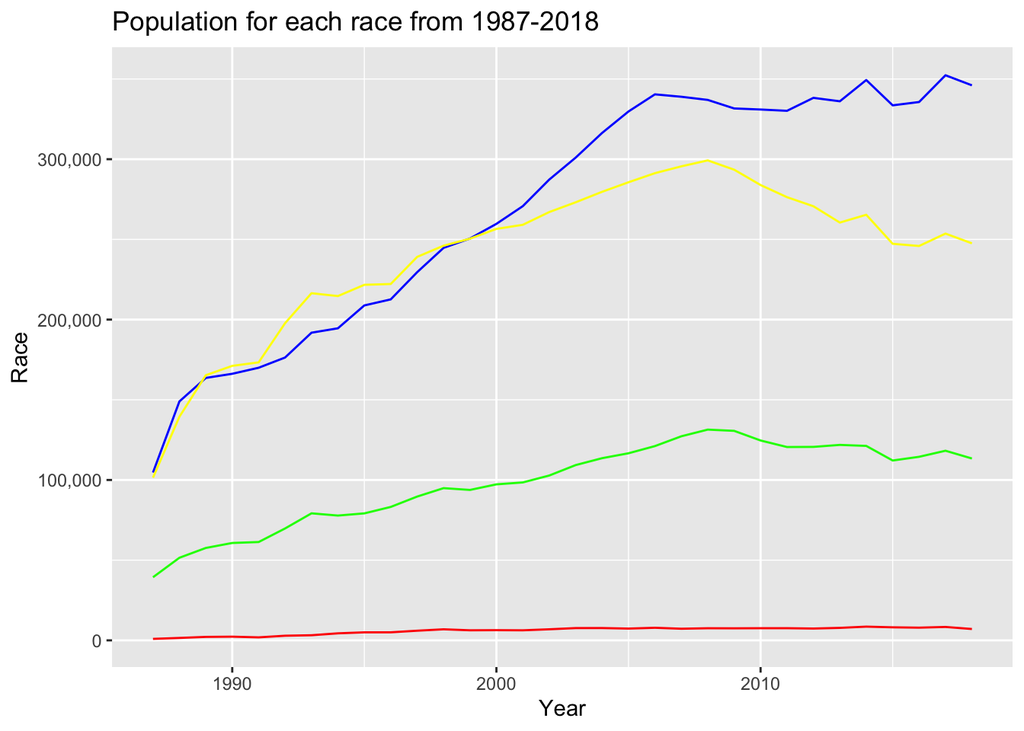